# Sparkify Project Workspace

This workspace contains a tiny subset (128MB) of the full dataset available (12GB). Feel free to use this workspace to build your project, or to explore a smaller subset with Spark before deploying your cluster on the cloud. Instructions for setting up your Spark cluster is included in the last lesson of the Extracurricular Spark Course content.

You can follow the steps below to guide your data analysis and model building portion of this project.

## Project Overview

The app contains data of a fictional music streaming service similar to Spotify. Goal is to predict which user is likely to churn. In order to keep the customers, discounts or special offers can be sent to the specific user.

```python
# import libraries

# install due seaborn update issue
!pip install -U seaborn


# pyspark sql
from pyspark.sql import Window
from pyspark.sql import SparkSession
from pyspark.sql import types as T
from pyspark.sql.functions import udf,col

# pyspark ml
from pyspark.ml.linalg import Vectors
from pyspark.ml import Pipeline
from pyspark.ml import feature as FT
from pyspark.ml.feature import VectorAssembler, StringIndexer, StandardScaler, Normalizer
from pyspark.ml.tuning import ParamGridBuilder, CrossValidator
from pyspark.ml.evaluation import MulticlassClassificationEvaluator
from pyspark.ml.classification import LogisticRegression, RandomForestClassifier, GBTClassifier, LinearSVC


# python libraries
import time
import datetime

# pandas
import pandas as pd

# seaborn
import seaborn as sns
sns.set(font_scale=3.0)
colors = ["#e74c3c","#046b3b","#2ecc71","#3498db", ]
sns.set_palette(colors)
sns.palplot(sns.color_palette())


# matplotlib
import matplotlib.pyplot as plt
%matplotlib inline
```

[output not shown]

```python
# create a Spark session
spark = SparkSession \
    .builder \
    .appName("Sparkify") \
    .getOrCreate()
```

# Load and Clean Dataset

In this workspace, the mini-dataset file is `mini_sparkify_event_data.json`. Load and clean the dataset, checking for invalid or missing data - for example, records without userids or sessionids.

```python
data = spark.read.json("mini_sparkify_event_data.json")
```

### Check structure of Dataset

```python
data.count()
```

```
286500
```

```python
data.take(1)
```

[output not shown]

```python
data.printSchema()
```

```
root
 |-- artist: string (nullable = true)
 |-- auth: string (nullable = true)
 |-- firstName: string (nullable = true)
 |-- gender: string (nullable = true)
 |-- itemInSession: long (nullable = true)
 |-- lastName: string (nullable = true)
 |-- length: double (nullable = true)
 |-- level: string (nullable = true)
 |-- location: string (nullable = true)
 |-- method: string (nullable = true)
 |-- page: string (nullable = true)
 |-- registration: long (nullable = true)
 |-- sessionId: long (nullable = true)
 |-- song: string (nullable = true)
 |-- status: long (nullable = true)
 |-- ts: long (nullable = true)
 |-- userAgent: string (nullable = true)
 |-- userId: string (nullable = true)
```

```python
data.select('page').distinct().show(25)
```

```
+--------------------+
|                page|
+--------------------+
|              Cancel|
|    Submit Downgrade|
|         Thumbs Down|
|                Home|
|           Downgrade|
|         Roll Advert|
|              Logout|
|       Save Settings|
|Cancellation Conf...|
|               About|
| Submit Registration|
|            Settings|
|               Login|
|            Register|
|     Add to Playlist|
|          Add Friend|
|            NextSong|
|           Thumbs Up|
|                Help|
|             Upgrade|
|               Error|
|      Submit Upgrade|
+--------------------+
```

## Clean Dataset

```python
def clean_data(data):
    '''
    Input: Dataset
    Output: Cleaned dataset
    '''
    # Remove duplicates in userId
    data.select("userId").dropDuplicates().count()
    # Remove strings and empty values
    data_clean = data.dropna(how = 'any', subset = ['userId', 'sessionId'])
    data_clean = data_clean.filter(data_clean['userId'] != '')
    return data_clean
```

```python
data = clean_data(data)
```

```python
data.count()
```

```
278154
```

## Convert time-related features

```python
def convert(data):
    '''
    Input: Dataset
    Output: Dataset with converted registration date and hour
    '''
    # Convert registration date
    get_date = udf(lambda x: datetime.datetime.fromtimestamp(x / 1000.0).strftime("%Y-%m-%d"))
    data = data.withColumn("registration_date", get_date(data.registration))
    # Convert hour
    get_hour = udf(lambda x: datetime.datetime.fromtimestamp(x / 1000.0).strftime("%H"))
    data = data.withColumn("hour", get_hour(data.ts))

    return data
```

```python
data = convert(data)
```

```python
data.select('hour').distinct().show(5)
```

```
+----+
|hour|
+----+
|  07|
|  15|
|  11|
|  01|
|  22|
+----+
only showing top 5 rows
```

```python
data.select('registration_date').distinct().show(5)
```

```
+-----------------+
|registration_date|
+-----------------+
|       2018-08-23|
|       2018-06-22|
|       2018-08-24|
|       2018-09-27|
|       2018-11-26|
+-----------------+
only showing top 5 rows
```

# Exploratory Data Analysis

When you're working with the full dataset, perform EDA by loading a small subset of the data and doing basic manipulations within Spark. In this workspace, you are already provided a small subset of data you can explore.

### Define Churn

Once you've done some preliminary analysis, create a column `Churn` to use as the label for your model. I suggest using the `Cancellation Confirmation` events to define your churn, which happen for both paid and free users. As a bonus task, you can also look into the `Downgrade` events.

### Churn defined by userId and Cancellation Confirmation

```python
def churn(data):
    '''
    Input: Dataset
    Output: Dataset of churned and non churned users
    '''
    data.createOrReplaceTempView('user_log_table')

    # data with churned users
    churned_users = spark.sql('SELECT DISTINCT userId, 1 as churn FROM user_log_table WHERE Page = "Cancellation Confirmation"')
    # data with non churned users
    non_churned_users = spark.sql('SELECT DISTINCT userId, 0 as churn FROM user_log_table \
                      WHERE userId NOT IN (SELECT DISTINCT userId FROM user_log_table WHERE Page = "Cancellation Confirmation")')

    # Creating a combined dataset of churned users and non churned users
    combined_churn = churned_users.union(non_churned_users)
    combined_churn.createOrReplaceTempView('churn_and_non_churn')
    combined_churn = spark.sql('SELECT * FROM churn_and_non_churn')

    return combined_churn
```

```python
combined_churn = churn(data)
```

```python
combined_churn.count()
```

```
225
```

#### Join on userId

```python
churn_data = data.join(combined_churn, on='userId')
```

```python
churn_data.select(['userId', 'churn']).distinct().show(5)
```

```
+------+-----+
|userId|churn|
+------+-----+
|100010|    0|
|200002|    0|
|   125|    1|
|   124|    0|
|    51|    1|
+------+-----+
only showing top 5 rows
```

```python
churn_data.select('page').distinct().show()
```

```
+--------------------+
|                page|
+--------------------+
|              Cancel|
|    Submit Downgrade|
|         Thumbs Down|
|                Home|
|           Downgrade|
|         Roll Advert|
|              Logout|
|       Save Settings|
|Cancellation Conf...|
|               About|
|            Settings|
|     Add to Playlist|
|          Add Friend|
|            NextSong|
|           Thumbs Up|
|                Help|
|             Upgrade|
|               Error|
|      Submit Upgrade|
+--------------------+
```

## Explore Data

### Check relation between features(Non page related features) and churn.

```python
churn_data.select("level").distinct().show()
```

```
+-----+
|level|
+-----+
| free|
| paid|
+-----+
```

```
Text(0.5,0.98,'Churned user by subscription-level')
```

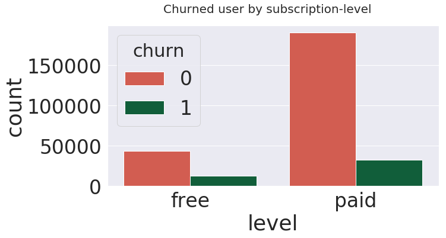

```python
# Plot Churned users by level of subscription
plt.figure(figsize=(10,5))
data_level=churn_data.groupby(["churn", "level"]).count().sort("churn").toPandas()
sns.barplot(x='level', y='count', hue='churn', data=data_level)
plt.suptitle('Churned user by subscription-level', fontsize=20)
```

```python
churn_data.select("location").distinct().count()
```

```
114
```

```
Text(0.5,0.98,'Churned user by location')
```

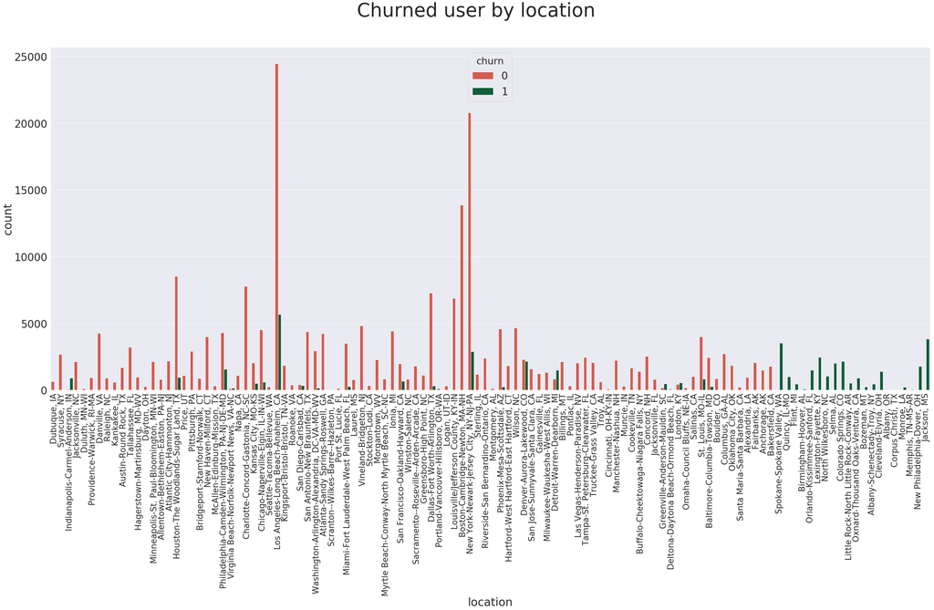

```python
# Plot churned user by level and location
plt.figure(figsize=(50,20))
data_location=churn_data.groupby(["location", "churn"]).count().sort("churn").toPandas()
data_location=sns.barplot(x='location', y='count', hue='churn', data=data_location);
plt.xticks(rotation=90, fontsize=26)
plt.suptitle('Churned user by location', fontsize=60)
```

# Feature Engineering

Once you've familiarized yourself with the data, build out the features you find promising to train your model on. To work with the full dataset, you can follow the following steps.

- Write a script to extract the necessary features from the smaller subset of data
- Ensure that your script is scalable, using the best practices discussed in Lesson 3
- Try your script on the full data set, debugging your script if necessary

If you are working in the classroom workspace, you can just extract features based on the small subset of data contained here. Be sure to transfer over this work to the larger dataset when you work on your Spark cluster.

### Following features has been used:

#### 1. Gender

#### 2. Thumps up

#### 3. Thumps down

#### 4. Listening time(length)

#### 5. Number of songs per user(song)

#### 6. Free or paid user(level)

```python
def features(data=churn_data):
    '''
    Input: Dataset
    Output: Dataset with features(Gender, Thumps up, Thumps down, Listening time,
                                  Number of songs per user, free or paid user) Changed churned to label and int.
    '''
    # Gender
    gender_num = churn_data\
           .select('userId','gender')\
           .dropDuplicates() \
           .replace(['M','F'],['0','1'],'gender')\
           .select('userId',col('gender').cast('int'))\
           .withColumnRenamed('gender', 'gender_num')

    # Thumbs up
    thumbs_up = churn_data \
             .select('userID','page') \
             .where(churn_data.page == 'Thumbs Up') \
             .groupBy('userID') \
             .count() \
             .withColumnRenamed('count', 'thumbs_up')

    # Thumps down
    thumbs_down = churn_data \
                 .select('userID','page') \
                 .where(churn_data.page == 'Thumbs Down') \
                 .groupBy('userID') \
                 .count() \
                 .withColumnRenamed('count', 'thumbs_down')

    # Listening Time
    listening_time = churn_data \
            .select('userId','length') \
            .groupby(['userId']) \
            .sum() \
            .withColumnRenamed('sum(length)','listening_time')

    # Number of songs per user
    song_per_user = churn_data \
                  .select("userId","song")\
                  .groupby("userId")\
                  .count()\
                  .withColumnRenamed("count","song_per_user")

    # Free or paid user to int
    level_num = churn_data \
         .select('userId','level')\
         .replace(['free','paid'],['0','1'],'level')\
         .select('userId',col('level').cast('int'))\
         .withColumnRenamed('level', 'level_num')

    # Change churn to label
    label = churn_data \
        .select('userId', col('churn').alias('label')) \
        .dropDuplicates()

    # Join dataset
    feature_data = song_per_user.join(gender_num,'userID','outer') \
              .join(thumbs_up,'userID','outer') \
              .join(thumbs_down, 'userID','outer') \
              .join(listening_time,'userID','outer') \
              .join(level_num,'userID','outer') \
              .join(label,'userID','outer') \
              .drop('userID') \
              .fillna(0)



    return feature_data
```

```python
feature_data = features(churn_data)
```

```python
feature_data.show(1)
```

```
+-------------+----------+---------+-----------+-----------------+---------+-----+
|song_per_user|gender_num|thumbs_up|thumbs_down|   listening_time|level_num|label|
+-------------+----------+---------+-----------+-----------------+---------+-----+
|          381|         1|       17|          5|66940.89735000003|        0|    0|
+-------------+----------+---------+-----------+-----------------+---------+-----+
only showing top 1 row
```

## Transform and scale features

```python
def transform_scale(feature_data):
    '''
    Input: Features
    Output: Transformed and scaled features
    '''
    # Transform features
    cols = ['song_per_user', 'gender_num', 'thumbs_up', 'thumbs_down','level_num','listening_time']
    assembler = VectorAssembler(inputCols=cols, outputCol="NumFeatures")
    data = assembler.transform(feature_data)

    # Scale features
    scaler = StandardScaler(inputCol="NumFeatures", outputCol="features", withStd=True)
    scalerModel = scaler.fit(data)
    data = scalerModel.transform(data)

    return data
```

```python
data = transform_scale(feature_data)
```

```python
data.show(1)
```

```
+-------------+----------+---------+-----------+-----------------+---------+-----+--------------------+--------------------+
|song_per_user|gender_num|thumbs_up|thumbs_down|   listening_time|level_num|label|         NumFeatures|            features|
+-------------+----------+---------+-----------+-----------------+---------+-----+--------------------+--------------------+
|          381|         1|       17|          5|66940.89735000003|        0|    0|[381.0,1.0,17.0,5...|[0.18187483384873...|
+-------------+----------+---------+-----------+-----------------+---------+-----+--------------------+--------------------+
only showing top 1 row
```

# Modeling

The Spark documentation shows that Spark doesn't support the entire sklearn library. In our case we have a binary classification problem. For this reason, we can choose from the following algorithms.

Logistic Regression, Gradient Boosted Tree, Random Forest, SVM, Naive Bayes.

Logistic Regression Gradient Boosted Tree Random Forest Classifier

I used Logistic Regression as a kind of a baseline model. It is easy to implement and it performs fast.

Gradient Boosted Tree and Random Forest Classifier are ensemble techniques based on decision trees.

Random Forest Classifier works well with huge datasets, we should take this into account if we train on the whole dataset.

Gradient Boosting performs well with imbalanced datasets, but the trade-off of Gradient Boosting and Random Forest is that they are prone to overfitting.

1. Train Models with default parameters
2. Choose best performing model
3. Hypertune parameters of chosen model

As mentioned previous, our dataset is imbalanced. For this reason, I choosed F1 score as the evaluation metric. F1 score is a combination of precision and recall.

#### Create train and validation dataset

```python
# Create training and validation dataset
train, validation = data.randomSplit([0.8, 0.2], seed=42)
```

### Train Models

#### 1. Model: Gradient Boosted Tree

#### 2. Model: Logistic Regression

#### 3. Model: Random Forest Classifier

```python
def ml_model_train_validate(model):
    start_time = time.time()

    f_score = MulticlassClassificationEvaluator(metricName='f1')

    model_train = model.fit(train)
    model_test = model_train.transform(validation)

    evaluator = MulticlassClassificationEvaluator(predictionCol='prediction')

    print("Model is:", model)
    print("Accuracy:")
    print(evaluator.evaluate(model_test,{evaluator.metricName: 'accuracy'}))
    print("F-1 score:")
    print(evaluator.evaluate(model_test, {evaluator.metricName: 'f1'}))
    print("%s seconds \n" % (time.time() - start_time))
    print("----------------------------------------\n")
    return model
```

```python
model = [GBTClassifier(), LogisticRegression(maxIter=10, regParam=0.3, elasticNetParam=0), RandomForestClassifier()]
for i in model:
    ml_model_train_validate(i)
```

```
Model is: GBTClassifier_d350e82cc54a
Accuracy:
0.9950848006913687
F-1 score:
0.9950544034611439
626.5252366065979 seconds

----------------------------------------

Model is: LogisticRegression_ae131fc51061
Accuracy:
0.8368801987684995
F-1 score:
0.7625630322111933
203.41978096961975 seconds

----------------------------------------

Model is: RandomForestClassifier_bf3771f2f91d
Accuracy:
0.8904072593712866
F-1 score:
0.8660554402134679
260.38772797584534 seconds

----------------------------------------
```

# Results

Gradient Boosted Tree: F-1 score: 0.995 Logistic Regression: F-1 score: 0.762 Random Forest: F-1 score: 0.866

# Refinement

```python
# Create training and validation dataset
train, validation = data.randomSplit([0.7, 0.3], seed=42)
```

```python
gb_hypertuned = GBTClassifier()
```

```python
# Tuning the hyperparameter
def ml_model_train_validate(model):
    start_time = time.time()

    f_score = MulticlassClassificationEvaluator(metricName='f1')

    #Tuning Hyperparameters
    paramGrid = ParamGridBuilder()\
       .addGrid(model.maxIter,[5,10])\
       .addGrid(model.maxDepth,[5,10]) \
       .build()


    crossval_gbt = CrossValidator(estimator=model,
                           evaluator=f_score,
                           estimatorParamMaps=paramGrid,
                           numFolds=3)



    model_train = model.fit(train)
    model_test = model_train.transform(validation)

    evaluator = MulticlassClassificationEvaluator(predictionCol='prediction')

    print("Model is:", model)
    print("Accuracy:")
    print(evaluator.evaluate(model_test,{evaluator.metricName: 'accuracy'}))
    print("F-1 score:")
    print(evaluator.evaluate(model_test, {evaluator.metricName: 'f1'}))
    print("%s seconds \n" % (time.time() - start_time))
    print("----------------------------------------\n")
    return model
```

```python
ml_model_train_validate(gb_hypertuned)
```

```
Model is: GBTClassifier_ae3703ece357
Accuracy:
0.9952568505487643
F-1 score:
0.9952284485854204
556.4192881584167 seconds

----------------------------------------
```

```
GBTClassifier_ae3703ece357
```

# Future Improvements

1. Training the model on the big dataset is essential for a production-ready application.
2. Extract and use more features, that would lead to a more robust model.
3. Tune Hyperparameters
4. Random over- or down-sampling could be applied in order to get a more balanced dataset.
5. If we aren't limited to Spark, we might apply other algorithms.

# Reflection

The most challenging aspects of the project was to get a good understanding of the data and which algorithm to choose. The dataset contains many user interactions. Therefore, at first glance it's a bit confusing. To get a better understanding it might be helpful to visualize it in more different plots. My first initial thought was that Random Forest would be a good choice for hyperparameter tuning due, the highly imbalanced dataset. Then I realised that if we train Gradient Boosted Tree on the whole dataset, overfitting will be less a problem. Gradient Boosted Tree needs about twice as long as Random Forest to train. In order to develop a real production application we need to ensure to train it on the whole dataset and that computation-time isn't that important. Let's assume we aren't bound to Spark, we could use other algorithms.